# Research Department Meeting Data Unit Overview

# SUMMARY

validated in the last two weeks: **25**  
median days from submission to validation: **7**  
maximum days from submission to validation: **37**  
under review: **23**  
delayed: **46**  
matrix inconsistencies: **302**

### How long did validations take?

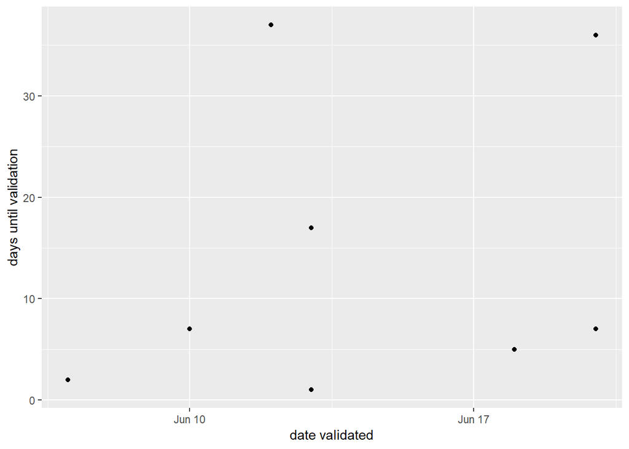

### Validated in the last two weeks

| rcid | file.id | comment | date.validated |
| --- | --- | --- | --- |
| SSD1701a | SSD1701a_AoK Quartely SO_Q1 19 - GBeG_analysis |  | 10-Jun-19 |
| IRQ1905 | IRQ1905_UNHCR MPCA Baseline Midline Endline_PDMAnalysis_1 |  | 11-Jun-19 |
| SOM1903 | SOM1903_Kismayo_Cash_Market_Feasability_Data_1 |  | 11-Jun-19 |
| SOM1903 | SOM1903_Kismayo_Cash_Market_Feasability_Analysis_1 |  | 11-Jun-19 |
| SOM1707b | SOM1707b_CCCM_Comprehensive_Site_Assessment_Round2_Data_1 | HH survey+ facility observations | 12-Jun-19 |
| IRQ1905 | IRQ1905_UNHCR MPCA Baseline Midline Endline_Data_1_Baseline |  | 13-Jun-19 |
| SOM1705 | SOM1705_WPM 2019 - April_Data/Analysis |  | 13-Jun-19 |
| SOM1707b | SOM1707b_CCCM_Comprehensive_Site_Assessment_Round2_Analysis_1 | HH survey+ facility observations | 13-Jun-19 |
| SOM1805b | SOM1805b_DSIRS_Thematic_Youth_Data_2_FGD_Bossaso |  | 13-Jun-19 |
| SOM1805b | SOM1805b_DSIRS_Thematic_Youth_Data_3_KI_Bossaso |  | 13-Jun-19 |
| SSD1708 | SSD1708_PRM_2019-5 - Renk data / analysis |  | 14-Jun-19 |
| SYR1706 | SYR1706a_Camp_Site_Mapping_data |  | 14-Jun-19 |
| SSD1701a | SSD1701a_Monthly Sectoral Analysis_2019_5_National_analysis |  | 18-Jun-19 |
| SYR1705 | SYR1705_Deir Ez Zor_Response_Round6_Data_1 |  | 18-Jun-19 |
| SYR1705 | SYR1705_Deir Ez Zor_Response_Round6_Analysis_1 |  | 18-Jun-19 |
| SYR1707b | SYR1707b_NES_ABA_Raqqa_Round5_Data_3 |  | 18-Jun-19 |
| SYR1707b | SYR1707b_NES_ABA_Raqqa_Round5_Analysis_3 |  | 18-Jun-19 |
| SOM1805b | SOM1805b_DSIRS_Thematic_Youth_Analysis_1_Individual_Survey_Bossaso |  | 19-Jun-19 |
| UKR1705 | UKR_1705 CVA round 5 HH and KI data |  | 19-Jun-19 |
| UKR1705 | UKR_1705 CVA round 5 HH and KI analysis |  | 19-Jun-19 |
| LBY1702 | LBY1702 JMMI 06-19 |  | 20-Jun-19 |
| NGA1902 | NGA1902_Maiduguri ABA_R2R_May_DEEPANALYSISFRAMEWORK |  | 20-Jun-19 |
| SYR1903 | SYR1903_Menbij_ABA_Data_1 |  | 20-Jun-19 |
| CAR1903 | CAR_1903_JMMI_Data_1_May 2019 |  | 7-Jun-19 |
| CAR1903 | CAR_1903_JMMI_Analysis_1_May 2019 |  | 7-Jun-19 |

### With HQ / Under Review

[output not shown]

### Delays

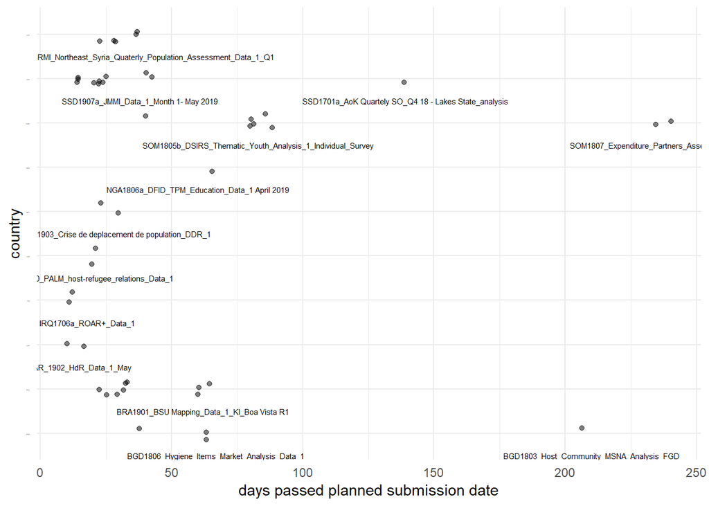

### total number of Comments

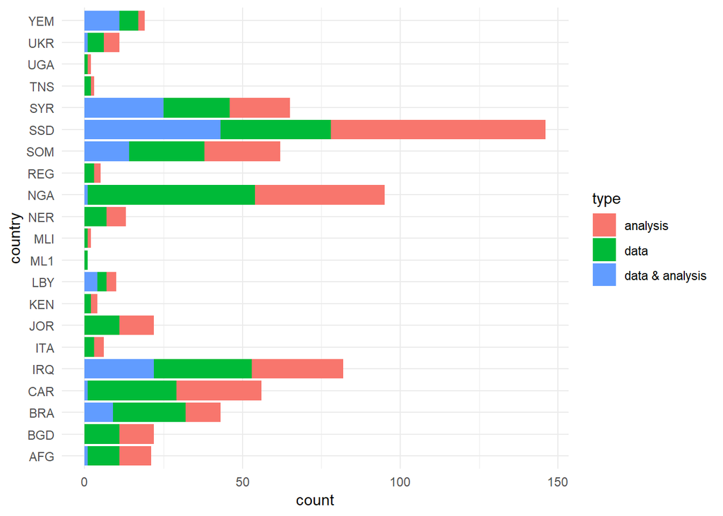

### RCM inconsistencies

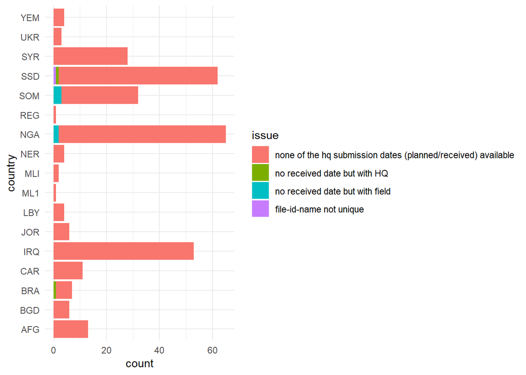

# BY COUNTRY

## AFG

### Recently Validated (2 weeks)

no items

### Under Review

| rcid | file.id | date.hqsubmission.actual |
| --- | --- | --- |
| AFG1901 | AFG1901_2019 MSNA_Data Analysis Plan_1 | 2019-05-28 |

### RCM inconsistencies

| id | issue | rcid | file id | comment | status | unit | country |
| --- | --- | --- | --- | --- | --- | --- | --- |
| 3 | none of the hq submission dates (planned/received) available | AFG1901 | [AFG1901_2019 MSNA_DDR_1](https://docs.google.com/spreadsheets/d/1wX5k3cETrCbnw4vpfY07eSzTyWX6AwmJmxJQwPahrSk/edit#gid=1191173775&range=2) |  |  | data | AFG |
| 4 | none of the hq submission dates (planned/received) available | AFG1901 | [AFG1901_2019 MSNA_Data_1_HH](https://docs.google.com/spreadsheets/d/1wX5k3cETrCbnw4vpfY07eSzTyWX6AwmJmxJQwPahrSk/edit#gid=1191173775&range=2) |  |  | data | AFG |
| 5 | none of the hq submission dates (planned/received) available | AFG1901 | [AFG1901_2019 MSNA_Data_2_HTR KI](https://docs.google.com/spreadsheets/d/1wX5k3cETrCbnw4vpfY07eSzTyWX6AwmJmxJQwPahrSk/edit#gid=1191173775&range=2) |  |  | data | AFG |
| 6 | none of the hq submission dates (planned/received) available | AFG1901 | [AFG1901_2019 MSNA_Data_3_FGD](https://docs.google.com/spreadsheets/d/1wX5k3cETrCbnw4vpfY07eSzTyWX6AwmJmxJQwPahrSk/edit#gid=1191173775&range=2) |  |  | data | AFG |
| 7 | none of the hq submission dates (planned/received) available | AFG1901 | [AFG1901_2019 MSNA_Analysis_1_HH](https://docs.google.com/spreadsheets/d/1wX5k3cETrCbnw4vpfY07eSzTyWX6AwmJmxJQwPahrSk/edit#gid=1191173775&range=2) |  |  | data | AFG |
| 8 | none of the hq submission dates (planned/received) available | AFG1901 | [AFG1901_2019 MSNA_Analysis_2_HTR KI](https://docs.google.com/spreadsheets/d/1wX5k3cETrCbnw4vpfY07eSzTyWX6AwmJmxJQwPahrSk/edit#gid=1191173775&range=2) |  |  | data | AFG |
| 9 | none of the hq submission dates (planned/received) available | AFG1901 | [AFG1901_2019 MSNA_Analysis_3_FGD](https://docs.google.com/spreadsheets/d/1wX5k3cETrCbnw4vpfY07eSzTyWX6AwmJmxJQwPahrSk/edit#gid=1191173775&range=2) |  |  | data | AFG |
| 10 | none of the hq submission dates (planned/received) available | AFG1902a | [AFG1902a_ERM MPCA Post Distribution Monitoring_Data_1_Round 1](https://docs.google.com/spreadsheets/d/1wX5k3cETrCbnw4vpfY07eSzTyWX6AwmJmxJQwPahrSk/edit#gid=1191173775&range=2) |  |  | data | AFG |
| 11 | none of the hq submission dates (planned/received) available | AFG1902a | [AFG1902a_ERM MPCA Post Distribution Monitoring_Analysis_1_Round 1](https://docs.google.com/spreadsheets/d/1wX5k3cETrCbnw4vpfY07eSzTyWX6AwmJmxJQwPahrSk/edit#gid=1191173775&range=2) |  |  | data | AFG |
| 12 | none of the hq submission dates (planned/received) available | AFG1902a | [AFG1902a_ERM MPCA Post Distribution Monitoring_Data_2_Round 2](https://docs.google.com/spreadsheets/d/1wX5k3cETrCbnw4vpfY07eSzTyWX6AwmJmxJQwPahrSk/edit#gid=1191173775&range=2) |  |  | data | AFG |
| 13 | none of the hq submission dates (planned/received) available | AFG1902a | [AFG1902a_ERM MPCA Post Distribution Monitoring_Analysis_2_Round 2](https://docs.google.com/spreadsheets/d/1wX5k3cETrCbnw4vpfY07eSzTyWX6AwmJmxJQwPahrSk/edit#gid=1191173775&range=2) |  |  | data | AFG |
| 14 | none of the hq submission dates (planned/received) available | AFG1902a | [AFG1902a_ERM MPCA Post Distribution Monitoring_Data_3_Round 3](https://docs.google.com/spreadsheets/d/1wX5k3cETrCbnw4vpfY07eSzTyWX6AwmJmxJQwPahrSk/edit#gid=1191173775&range=2) |  |  | data | AFG |
| 15 | none of the hq submission dates (planned/received) available | AFG1902a | [AFG1902a_ERM MPCA Post Distribution Monitoring_Analysis_3_Round 3](https://docs.google.com/spreadsheets/d/1wX5k3cETrCbnw4vpfY07eSzTyWX6AwmJmxJQwPahrSk/edit#gid=1191173775&range=2) |  |  | data | AFG |

### Delays

no known delays

### Comments

| rcid | file.id | comment |
| --- | --- | --- |
| AFG1803 | AFG1803_AGORA_Analysis_3_HH | Not public; postponed |
| AFG1902b | AFG1902b_ERM Qualitative Longitudinal Study_Data_1 | Round 1 analysis and outputs will also include data collected in the baseline in July 2019 |
| AFG1902b | AFG1902b_ERM Qualitative Longitudinal Study_Analysis_1 | Round 1 analysis and outputs will also include data collected in the baseline in July 2019 |

## BGD

### Recently Validated (2 weeks)

no items

### Under Review

| rcid | file.id | date.hqsubmission.actual |
| --- | --- | --- |
| BGD1803 | BGD1803_Host_Community_MSNA_Data_FGD | 2019-06-04 |

### RCM inconsistencies

|  | id | issue | rcid | file id | comment | status | unit | country |
| --- | --- | --- | --- | --- | --- | --- | --- | --- |
| 14 | 24 | none of the hq submission dates (planned/received) available | BGD1703 | [BGD1703_UNHCR SPP_Data_1_October](https://docs.google.com/spreadsheets/d/1wX5k3cETrCbnw4vpfY07eSzTyWX6AwmJmxJQwPahrSk/edit#gid=1191173775&range=2) |  |  | data | BGD |
| 15 | 25 | none of the hq submission dates (planned/received) available | BGD1703 | [BGD1703_UNHCR SPP_Analysis_1_October](https://docs.google.com/spreadsheets/d/1wX5k3cETrCbnw4vpfY07eSzTyWX6AwmJmxJQwPahrSk/edit#gid=1191173775&range=2) |  |  | data | BGD |
| 16 | 38 | none of the hq submission dates (planned/received) available | BGD1902b | [BGD1902b_MSNA 2_JRP End of Year_Data_1](https://docs.google.com/spreadsheets/d/1wX5k3cETrCbnw4vpfY07eSzTyWX6AwmJmxJQwPahrSk/edit#gid=1191173775&range=2) |  |  | data | BGD |
| 17 | 39 | none of the hq submission dates (planned/received) available | BGD1902b | [BGD1902b_MSNA 2_JRP End of Year_Analysis_1](https://docs.google.com/spreadsheets/d/1wX5k3cETrCbnw4vpfY07eSzTyWX6AwmJmxJQwPahrSk/edit#gid=1191173775&range=2) |  |  | data | BGD |
| 18 | 41 | none of the hq submission dates (planned/received) available | BGD1905 | [BGD1905_WASH Infra Quality_data_2](https://docs.google.com/spreadsheets/d/1wX5k3cETrCbnw4vpfY07eSzTyWX6AwmJmxJQwPahrSk/edit#gid=1191173775&range=2) |  |  | data | BGD |
| 19 | 43 | none of the hq submission dates (planned/received) available | BGD1905 | [BGD1905_WASH Infra Quality_analysis_2](https://docs.google.com/spreadsheets/d/1wX5k3cETrCbnw4vpfY07eSzTyWX6AwmJmxJQwPahrSk/edit#gid=1191173775&range=2) |  |  | data | BGD |

### Delays

| rcid | file.id | days_delayed |
| --- | --- | --- |
| BGD1803 | BGD1803_Host_Community_MSNA_Analysis_FGD | 210 days |
| BGD1806 | BGD1806_Hygiene_Items_Market_Analysis_Data_1 | 67 days |
| BGD1806 | BGD1806_Hygiene_Items_Market_Analysis_Analysis_1 | 67 days |
| BGD1801b | BGD1801b_WASH 2019 HH Assessment_Analysis_1 | 38 days |

### Comments

| rcid | file.id | comment |
| --- | --- | --- |
| BGD1803 | BGD1803_Host_Community_MSNA_Data_FGD | received after explicit follow up, will be reviewed a posteriori |
| BGD1803 | BGD1803_Host_Community_MSNA_Data_HH Survey | Survey data |
| BGD1803 | BGD1803_Host_Community_MSNA_Analysis_HH Survey | Survey data |

## BRA

### Recently Validated (2 weeks)

no items

### Under Review

| rcid | file.id | date.hqsubmission.actual |
| --- | --- | --- |
| BRA1901 | BRA1901_BSU Mapping_Data_2_Participatory Mapping_Boa Vista R1 | NA |

### RCM inconsistencies

|  | id | issue | rcid | file id | comment | status | unit | country |
| --- | --- | --- | --- | --- | --- | --- | --- | --- |
| 20 | 63 | none of the hq submission dates (planned/received) available | BRA1902 | [BRA1902_FDG_Boa_Vista_July 2019](https://docs.google.com/spreadsheets/d/1wX5k3cETrCbnw4vpfY07eSzTyWX6AwmJmxJQwPahrSk/edit#gid=1191173775&range=2) |  |  | data | BRA |
| 21 | 64 | none of the hq submission dates (planned/received) available | BRA1902 | [BRA1902_FDG_Boa_Vista_August 2019](https://docs.google.com/spreadsheets/d/1wX5k3cETrCbnw4vpfY07eSzTyWX6AwmJmxJQwPahrSk/edit#gid=1191173775&range=2) |  |  | data | BRA |
| 22 | 65 | none of the hq submission dates (planned/received) available | BRA1902 | [BRA1902_FDG_Boa_Vista_September 2019](https://docs.google.com/spreadsheets/d/1wX5k3cETrCbnw4vpfY07eSzTyWX6AwmJmxJQwPahrSk/edit#gid=1191173775&range=2) |  |  | data | BRA |
| 23 | 66 | none of the hq submission dates (planned/received) available | BRA1902 | [BRA1902_FDG_Boa_Vista_October 2019](https://docs.google.com/spreadsheets/d/1wX5k3cETrCbnw4vpfY07eSzTyWX6AwmJmxJQwPahrSk/edit#gid=1191173775&range=2) |  |  | data | BRA |
| 24 | 67 | none of the hq submission dates (planned/received) available | BRA1902 | [BRA1902_FDG_Boa_Vista_November 2019](https://docs.google.com/spreadsheets/d/1wX5k3cETrCbnw4vpfY07eSzTyWX6AwmJmxJQwPahrSk/edit#gid=1191173775&range=2) |  |  | data | BRA |
| 25 | 68 | none of the hq submission dates (planned/received) available | BRA1902 | [BRA1902_FDG_Boa_Vista_December 2019](https://docs.google.com/spreadsheets/d/1wX5k3cETrCbnw4vpfY07eSzTyWX6AwmJmxJQwPahrSk/edit#gid=1191173775&range=2) |  |  | data | BRA |
| 295 | 45 | no received date but with HQ | BRA1901 | [BRA1901_BSU Mapping_Data_2_Participatory Mapping_Boa Vista R1](https://docs.google.com/spreadsheets/d/1wX5k3cETrCbnw4vpfY07eSzTyWX6AwmJmxJQwPahrSk/edit#gid=1191173775&range=2) |  | 2 with HQ | data | BRA |

### Delays

| rcid | file.id | days_delayed |
| --- | --- | --- |
| BRA1901 | BRA1901_BSU Mapping_Data_1_KI_Boa Vista R1 | 62 days |
| BRA1901 | BRA1901_BSU Mapping_Data_1_KI_Manaus R1 | 55 days |
| BRA1901 | BRA1901_BSU Mapping_Data_2_Participatory Mapping_Manaus R1 | 55 days |
| BRA1902 | BRA1902_ABA_Data_1_KII_Boa Vista R1 | 27 days |
| BRA1902 | BRA1902_ABA_Data_2_FGD_Boa Vista R1 | 27 days |
| BRA1902 | BRA1902_ABA_Data_3_HH Survey_Boa Vista R1 | 27 days |
| BRA1902 | BRA1902_ABA_Analysis_1_KII_Boa Vista R1 | 27 days |
| BRA1902 | BRA1902_ABA_Analysis_2_FGD_Boa Vista R1 | 27 days |
| BRA1902 | BRA1902_ABA_Analysis_3_HH Survey_Boa Vista R1 | 27 days |

### Comments

| rcid | file.id | comment |
| --- | --- | --- |
| BRA1902 | BRA1902_ABA_Data_1_KII_Boa Vista R1 | 3 types of KIIs per round: host community, service providers, community promoters |
| BRA1902 | BRA1902_ABA_Analysis_1_KII_Boa Vista R1 | 3 types of KIIs per round: host community, service providers, community promoters |
| BRA1902 | BRA1902_ABA_Data_1_KII_Manaus R2 | 3 types of KIIs per round: host community, service providers, community promoters |
| BRA1902 | BRA1902_ABA_Analysis_1_KII_Manaus R2 | 3 types of KIIs per round: host community, service providers, community promoters |
| BRA1903 | BRA1903_Interiorisation_Data_1_HH Survey 1 | Pre-departure baseline survey |
| BRA1903 | BRA1903_Interiorisation_Data_2_HH Survey 2 | Follow up survey with post-departure cohort |
| BRA1903 | BRA1903_Interiorisation_Data_3_HH Survey 3 | Survey with those resettled >4 months |

## CAR

### Recently Validated (2 weeks)

| rcid | file.id | comment | days_since_validation |
| --- | --- | --- | --- |
| CAR1903 | CAR_1903_JMMI_Data_1_May 2019 |  | 13 |
| CAR1903 | CAR_1903_JMMI_Analysis_1_May 2019 |  | 13 |

### Under Review

| rcid | file.id | date.hqsubmission.actual |
| --- | --- | --- |
| CAR1901 | CAR_1901_MSNA_Data Analysis Plan_1 | 2019-05-27 |

### RCM inconsistencies

|  | id | issue | rcid | file id | comment | status | unit | country |
| --- | --- | --- | --- | --- | --- | --- | --- | --- |
| 26 | 90 | none of the hq submission dates (planned/received) available | CAR1901 | [CAR_1901_MSNA_Data_1_HH](https://docs.google.com/spreadsheets/d/1wX5k3cETrCbnw4vpfY07eSzTyWX6AwmJmxJQwPahrSk/edit#gid=1191173775&range=2) |  |  | data | CAR |
| 27 | 91 | none of the hq submission dates (planned/received) available | CAR1901 | [CAR_1901_MSNA_Analysis_1_HH](https://docs.google.com/spreadsheets/d/1wX5k3cETrCbnw4vpfY07eSzTyWX6AwmJmxJQwPahrSk/edit#gid=1191173775&range=2) |  |  | data | CAR |
| 28 | 92 | none of the hq submission dates (planned/received) available | CAR1901 | [CAR_1901_MSNA_Data_2_KI](https://docs.google.com/spreadsheets/d/1wX5k3cETrCbnw4vpfY07eSzTyWX6AwmJmxJQwPahrSk/edit#gid=1191173775&range=2) |  |  | data | CAR |
| 29 | 93 | none of the hq submission dates (planned/received) available | CAR1901 | [CAR_1901_MSNA_Analysis_2_KI](https://docs.google.com/spreadsheets/d/1wX5k3cETrCbnw4vpfY07eSzTyWX6AwmJmxJQwPahrSk/edit#gid=1191173775&range=2) |  |  | data | CAR |
| 30 | 94 | none of the hq submission dates (planned/received) available | CAR1901 | [CAR_1901_MSNA_Data Deletion Report_1](https://docs.google.com/spreadsheets/d/1wX5k3cETrCbnw4vpfY07eSzTyWX6AwmJmxJQwPahrSk/edit#gid=1191173775&range=2) |  |  | data | CAR |
| 31 | 137 | none of the hq submission dates (planned/received) available | CAR1904 | [CAR_1904_Ad_Hoc_Market_Assessment_Data_](https://docs.google.com/spreadsheets/d/1wX5k3cETrCbnw4vpfY07eSzTyWX6AwmJmxJQwPahrSk/edit#gid=1191173775&range=2) |  |  | data | CAR |
| 32 | 138 | none of the hq submission dates (planned/received) available | CAR1904 | [CAR_1904_Ad_Hoc_Market_Assessment_Analysis](https://docs.google.com/spreadsheets/d/1wX5k3cETrCbnw4vpfY07eSzTyWX6AwmJmxJQwPahrSk/edit#gid=1191173775&range=2) |  |  | data | CAR |
| 33 | 139 | none of the hq submission dates (planned/received) available | CAR1905 | [CAR_1905_Education_Infrastructures_Mapping_Data_](https://docs.google.com/spreadsheets/d/1wX5k3cETrCbnw4vpfY07eSzTyWX6AwmJmxJQwPahrSk/edit#gid=1191173775&range=2) | On hold until fall till schools reopen after summer holidays |  | data | CAR |
| 34 | 140 | none of the hq submission dates (planned/received) available | CAR1905 | [CAR_1905_Education_Infrastructures_Mapping_Analysis_](https://docs.google.com/spreadsheets/d/1wX5k3cETrCbnw4vpfY07eSzTyWX6AwmJmxJQwPahrSk/edit#gid=1191173775&range=2) | On hold until fall till schools reopen after summer holidays |  | data | CAR |
| 35 | 141 | none of the hq submission dates (planned/received) available | CAR1906 | [CAR_1906_Education_Needs_Displaced_Population_Data_](https://docs.google.com/spreadsheets/d/1wX5k3cETrCbnw4vpfY07eSzTyWX6AwmJmxJQwPahrSk/edit#gid=1191173775&range=2) | On hold until fall till schools reopen after summer holidays |  | data | CAR |
| 36 | 142 | none of the hq submission dates (planned/received) available | CAR1906 | [CAR_1906_Education_Needs_Displaced_Population_Analysis_](https://docs.google.com/spreadsheets/d/1wX5k3cETrCbnw4vpfY07eSzTyWX6AwmJmxJQwPahrSk/edit#gid=1191173775&range=2) | On hold until fall till schools reopen after summer holidays |  | data | CAR |

### Delays

| rcid | file.id | days_delayed |
| --- | --- | --- |
| CAR1902 | CAR_1902_HdR_Data_1_May | 15 days |
| CAR1902 | CAR_1902_HdR_Analysis_1_May | 15 days |

### Comments

| rcid | file.id | comment |
| --- | --- | --- |
| CAR1701b | CAR1701b_RRM_MSA_Analysis_1 | some issues with data valid, file for which vlidation requested not fully cleaned, and re-sent a second version, better to avoid in future |
| CAR1905 | CAR_1905_Education_Infrastructures_Mapping_Data_ | On hold until fall till schools reopen after summer holidays |
| CAR1905 | CAR_1905_Education_Infrastructures_Mapping_Analysis_ | On hold until fall till schools reopen after summer holidays |
| CAR1906 | CAR_1906_Education_Needs_Displaced_Population_Data_ | On hold until fall till schools reopen after summer holidays |
| CAR1906 | CAR_1906_Education_Needs_Displaced_Population_Analysis_ | On hold until fall till schools reopen after summer holidays |

## IRQ

### Recently Validated (2 weeks)

| rcid | file.id | comment | days_since_validation |
| --- | --- | --- | --- |
| IRQ1905 | IRQ1905_UNHCR MPCA Baseline Midline Endline_Data_1_Baseline |  | 7 |
| IRQ1905 | IRQ1905_UNHCR MPCA Baseline Midline Endline_PDMAnalysis_1 |  | 9 |

### Under Review

| rcid | file.id | date.hqsubmission.actual |
| --- | --- | --- |
| IRQ1807a | IRQ1807a_Ninewa_Context_Monitoring_data_and_analysis_19_06 | 2019-06-14 |

### RCM inconsistencies

|  | id | issue | rcid | file id | comment | status | unit | country |
| --- | --- | --- | --- | --- | --- | --- | --- | --- |
| 37 | 144 | none of the hq submission dates (planned/received) available | IRQ1703 | [Price Monitoring Data+Analysis Round 26](https://docs.google.com/spreadsheets/d/1wX5k3cETrCbnw4vpfY07eSzTyWX6AwmJmxJQwPahrSk/edit#gid=1191173775&range=2) |  | 1 not received | data | IRQ |
| 38 | 145 | none of the hq submission dates (planned/received) available | IRQ1703 | [Price Monitoring Data+Analysis Round 27](https://docs.google.com/spreadsheets/d/1wX5k3cETrCbnw4vpfY07eSzTyWX6AwmJmxJQwPahrSk/edit#gid=1191173775&range=2) |  | 1 not received | data | IRQ |
| 39 | 146 | none of the hq submission dates (planned/received) available | IRQ1703 | [Price Monitoring Data+Analysis Round 28](https://docs.google.com/spreadsheets/d/1wX5k3cETrCbnw4vpfY07eSzTyWX6AwmJmxJQwPahrSk/edit#gid=1191173775&range=2) |  | 1 not received | data | IRQ |
| 40 | 147 | none of the hq submission dates (planned/received) available | IRQ1703 | [Price Monitoring Data+Analysis Round 29](https://docs.google.com/spreadsheets/d/1wX5k3cETrCbnw4vpfY07eSzTyWX6AwmJmxJQwPahrSk/edit#gid=1191173775&range=2) |  | 1 not received | data | IRQ |
| 41 | 148 | none of the hq submission dates (planned/received) available | IRQ1703 | [Price Monitoring Data+Analysis Round 30](https://docs.google.com/spreadsheets/d/1wX5k3cETrCbnw4vpfY07eSzTyWX6AwmJmxJQwPahrSk/edit#gid=1191173775&range=2) |  | 1 not received | data | IRQ |
| 42 | 149 | none of the hq submission dates (planned/received) available | IRQ1703 | [Price Monitoring Data+Analysis Round 31](https://docs.google.com/spreadsheets/d/1wX5k3cETrCbnw4vpfY07eSzTyWX6AwmJmxJQwPahrSk/edit#gid=1191173775&range=2) |  | 1 not received | data | IRQ |
| 43 | 150 | none of the hq submission dates (planned/received) available | IRQ1703 | [Price Monitoring Data+Analysis Round 32](https://docs.google.com/spreadsheets/d/1wX5k3cETrCbnw4vpfY07eSzTyWX6AwmJmxJQwPahrSk/edit#gid=1191173775&range=2) |  | 1 not received | data | IRQ |
| 44 | 151 | none of the hq submission dates (planned/received) available | IRQ1703 | [Price Monitoring Data+Analysis Round 33](https://docs.google.com/spreadsheets/d/1wX5k3cETrCbnw4vpfY07eSzTyWX6AwmJmxJQwPahrSk/edit#gid=1191173775&range=2) | Planned up to Round 32 only due to current visibility on funding | 1 not received | data | IRQ |
| 45 | 152 | none of the hq submission dates (planned/received) available | IRQ1703 | [Price Monitoring Data+Analysis Round 34](https://docs.google.com/spreadsheets/d/1wX5k3cETrCbnw4vpfY07eSzTyWX6AwmJmxJQwPahrSk/edit#gid=1191173775&range=2) | Planned up to Round 32 only due to current visibility on funding | 1 not received | data | IRQ |
| 46 | 153 | none of the hq submission dates (planned/received) available | IRQ1703 | [Price Monitoring Data+Analysis Round 35](https://docs.google.com/spreadsheets/d/1wX5k3cETrCbnw4vpfY07eSzTyWX6AwmJmxJQwPahrSk/edit#gid=1191173775&range=2) | Planned up to Round 32 only due to current visibility on funding | 1 not received | data | IRQ |
| 47 | 154 | none of the hq submission dates (planned/received) available | IRQ1703 | [Price Monitoring Data+Analysis Round 36](https://docs.google.com/spreadsheets/d/1wX5k3cETrCbnw4vpfY07eSzTyWX6AwmJmxJQwPahrSk/edit#gid=1191173775&range=2) | Planned up to Round 32 only due to current visibility on funding | 1 not received | data | IRQ |
| 48 | 155 | none of the hq submission dates (planned/received) available | IRQ1703 | [Price Monitoring Data+Analysis Round 37](https://docs.google.com/spreadsheets/d/1wX5k3cETrCbnw4vpfY07eSzTyWX6AwmJmxJQwPahrSk/edit#gid=1191173775&range=2) | Planned up to Round 32 only due to current visibility on funding | 1 not received | data | IRQ |
| 49 | 156 | none of the hq submission dates (planned/received) available | IRQ1703 | [Price Monitoring Data+Analysis Round 38](https://docs.google.com/spreadsheets/d/1wX5k3cETrCbnw4vpfY07eSzTyWX6AwmJmxJQwPahrSk/edit#gid=1191173775&range=2) | Planned up to Round 32 only due to current visibility on funding | 1 not received | data | IRQ |
| 50 | 157 | none of the hq submission dates (planned/received) available | IRQ1703 | [Price Monitoring Data+Analysis Round 39](https://docs.google.com/spreadsheets/d/1wX5k3cETrCbnw4vpfY07eSzTyWX6AwmJmxJQwPahrSk/edit#gid=1191173775&range=2) | Planned up to Round 32 only due to current visibility on funding | 1 not received | data | IRQ |
| 51 | 158 | none of the hq submission dates (planned/received) available | IRQ1703 | [Price Monitoring Data+Analysis Round 40](https://docs.google.com/spreadsheets/d/1wX5k3cETrCbnw4vpfY07eSzTyWX6AwmJmxJQwPahrSk/edit#gid=1191173775&range=2) | Planned up to Round 32 only due to current visibility on funding | 1 not received | data | IRQ |
| 52 | 159 | none of the hq submission dates (planned/received) available | IRQ1703 | [Price Monitoring Data+Analysis Round 41](https://docs.google.com/spreadsheets/d/1wX5k3cETrCbnw4vpfY07eSzTyWX6AwmJmxJQwPahrSk/edit#gid=1191173775&range=2) | Planned up to Round 32 only due to current visibility on funding | 1 not received | data | IRQ |
| 53 | 160 | none of the hq submission dates (planned/received) available | IRQ1703 | [Price Monitoring Data+Analysis Round 42](https://docs.google.com/spreadsheets/d/1wX5k3cETrCbnw4vpfY07eSzTyWX6AwmJmxJQwPahrSk/edit#gid=1191173775&range=2) | Planned up to Round 32 only due to current visibility on funding | 1 not received | data | IRQ |
| 54 | 161 | none of the hq submission dates (planned/received) available | IRQ1704d | [IRQ1704_UNHCR PDM_Report_KRI 2017-2018 Cash for Winterization DATA](https://docs.google.com/spreadsheets/d/1wX5k3cETrCbnw4vpfY07eSzTyWX6AwmJmxJQwPahrSk/edit#gid=1191173775&range=2) |  | 3 validated | data | IRQ |
| 55 | 163 | none of the hq submission dates (planned/received) available | IRQ1705 | [IRQ1705_Camp profiling_Round 13_data+analysis](https://docs.google.com/spreadsheets/d/1wX5k3cETrCbnw4vpfY07eSzTyWX6AwmJmxJQwPahrSk/edit#gid=1191173775&range=2) | Template received on 04/09 |  | data | IRQ |
| 56 | 167 | none of the hq submission dates (planned/received) available | IRQ1710 | [IRQ1710a_Area-based_Assessment_mosul_hhdata](https://docs.google.com/spreadsheets/d/1wX5k3cETrCbnw4vpfY07eSzTyWX6AwmJmxJQwPahrSk/edit#gid=1191173775&range=2) |  | 3 validated | data | IRQ |
| 57 | 168 | none of the hq submission dates (planned/received) available | IRQ1710 | [IRQ1710_Area-based_Assessment_mosul_Syntax/Analysis_V1](https://docs.google.com/spreadsheets/d/1wX5k3cETrCbnw4vpfY07eSzTyWX6AwmJmxJQwPahrSk/edit#gid=1191173775&range=2) |  | 3 validated | data | IRQ |
| 58 | 172 | none of the hq submission dates (planned/received) available | IRQ1803 | [IRQ1803_comprehensive_baseline_assessment_UNHCR_MPCA_Data_1](https://docs.google.com/spreadsheets/d/1wX5k3cETrCbnw4vpfY07eSzTyWX6AwmJmxJQwPahrSk/edit#gid=1191173775&range=2) |  | 3 validated | data | IRQ |
| 59 | 178 | none of the hq submission dates (planned/received) available | IRQ1807b | [IRQ1807b_GIZ_Endline_Data_1_HH Survey](https://docs.google.com/spreadsheets/d/1wX5k3cETrCbnw4vpfY07eSzTyWX6AwmJmxJQwPahrSk/edit#gid=1191173775&range=2) |  |  | data | IRQ |
| 60 | 179 | none of the hq submission dates (planned/received) available | IRQ1807b | [IRQ1807b_GIZ_Endline_Data_2_KII & FGDs](https://docs.google.com/spreadsheets/d/1wX5k3cETrCbnw4vpfY07eSzTyWX6AwmJmxJQwPahrSk/edit#gid=1191173775&range=2) |  |  | data | IRQ |
| 61 | 180 | none of the hq submission dates (planned/received) available | IRQ1807b | [IRQ1807b_GIZ_Endline_Analysis_1_HH Surveys](https://docs.google.com/spreadsheets/d/1wX5k3cETrCbnw4vpfY07eSzTyWX6AwmJmxJQwPahrSk/edit#gid=1191173775&range=2) |  |  | data | IRQ |
| 62 | 181 | none of the hq submission dates (planned/received) available | IRQ1807b | [IRQ1807b_GIZ_Endline_Analysis_2_KII & FGDs](https://docs.google.com/spreadsheets/d/1wX5k3cETrCbnw4vpfY07eSzTyWX6AwmJmxJQwPahrSk/edit#gid=1191173775&range=2) |  |  | data | IRQ |
| 63 | 195 | none of the hq submission dates (planned/received) available | IRQ1905 | [IRQ1905_UNHCR MPCA Baseline Midline Endline_Data_1_Baseline](https://docs.google.com/spreadsheets/d/1wX5k3cETrCbnw4vpfY07eSzTyWX6AwmJmxJQwPahrSk/edit#gid=1191173775&range=2) |  | 3 validated | data | IRQ |
| 64 | 196 | none of the hq submission dates (planned/received) available | IRQ1905 | [IRQ1905_UNHCR MPCA Baseline Midline Endline_PDMData_1](https://docs.google.com/spreadsheets/d/1wX5k3cETrCbnw4vpfY07eSzTyWX6AwmJmxJQwPahrSk/edit#gid=1191173775&range=2) |  | 3 validated | data | IRQ |
| 65 | 197 | none of the hq submission dates (planned/received) available | IRQ1905 | [IRQ1905_UNHCR MPCA Baseline Midline Endline_PDMAnalysis_1](https://docs.google.com/spreadsheets/d/1wX5k3cETrCbnw4vpfY07eSzTyWX6AwmJmxJQwPahrSk/edit#gid=1191173775&range=2) |  | 3 validated | data | IRQ |
| 66 | 198 | none of the hq submission dates (planned/received) available | IRQ1905 | [IRQ1905_UNHCR MPCA Baseline Midline Endline_PDMData_2](https://docs.google.com/spreadsheets/d/1wX5k3cETrCbnw4vpfY07eSzTyWX6AwmJmxJQwPahrSk/edit#gid=1191173775&range=2) |  |  | data | IRQ |
| 67 | 199 | none of the hq submission dates (planned/received) available | IRQ1905 | [IRQ1905_UNHCR MPCA Baseline Midline Endline_PDMAnalysis_2](https://docs.google.com/spreadsheets/d/1wX5k3cETrCbnw4vpfY07eSzTyWX6AwmJmxJQwPahrSk/edit#gid=1191173775&range=2) |  |  | data | IRQ |
| 68 | 200 | none of the hq submission dates (planned/received) available | IRQ1905 | [IRQ1905_UNHCR MPCA Baseline Midline Endline_PDMData_3](https://docs.google.com/spreadsheets/d/1wX5k3cETrCbnw4vpfY07eSzTyWX6AwmJmxJQwPahrSk/edit#gid=1191173775&range=2) |  |  | data | IRQ |
| 69 | 201 | none of the hq submission dates (planned/received) available | IRQ1905 | [IRQ1905_UNHCR MPCA Baseline Midline Endline_PDMAnalysis_3](https://docs.google.com/spreadsheets/d/1wX5k3cETrCbnw4vpfY07eSzTyWX6AwmJmxJQwPahrSk/edit#gid=1191173775&range=2) |  |  | data | IRQ |
| 70 | 202 | none of the hq submission dates (planned/received) available | IRQ1905 | [IRQ1905_UNHCR MPCA Baseline Midline Endline_PDMData_4](https://docs.google.com/spreadsheets/d/1wX5k3cETrCbnw4vpfY07eSzTyWX6AwmJmxJQwPahrSk/edit#gid=1191173775&range=2) |  |  | data | IRQ |
| 71 | 203 | none of the hq submission dates (planned/received) available | IRQ1905 | [IRQ1905_UNHCR MPCA Baseline Midline Endline_PDMAnalysis_4](https://docs.google.com/spreadsheets/d/1wX5k3cETrCbnw4vpfY07eSzTyWX6AwmJmxJQwPahrSk/edit#gid=1191173775&range=2) |  |  | data | IRQ |
| 72 | 204 | none of the hq submission dates (planned/received) available | IRQ1905 | [IRQ1905_UNHCR MPCA Baseline Midline Endline_Data_1_First Midline_HH](https://docs.google.com/spreadsheets/d/1wX5k3cETrCbnw4vpfY07eSzTyWX6AwmJmxJQwPahrSk/edit#gid=1191173775&range=2) |  |  | data | IRQ |
| 73 | 205 | none of the hq submission dates (planned/received) available | IRQ1905 | [IRQ1905_UNHCR MPCA Baseline Midline Endline_Data_2_First Midline_FGD](https://docs.google.com/spreadsheets/d/1wX5k3cETrCbnw4vpfY07eSzTyWX6AwmJmxJQwPahrSk/edit#gid=1191173775&range=2) |  |  | data | IRQ |
| 74 | 206 | none of the hq submission dates (planned/received) available | IRQ1905 | [IRQ1905_UNHCR MPCA Baseline Midline Endline_Analysis_1_First Midline_HH](https://docs.google.com/spreadsheets/d/1wX5k3cETrCbnw4vpfY07eSzTyWX6AwmJmxJQwPahrSk/edit#gid=1191173775&range=2) |  |  | data | IRQ |
| 75 | 207 | none of the hq submission dates (planned/received) available | IRQ1905 | [IRQ1905_UNHCR MPCA Baseline Midline Endline_Analysis_2_First Midline_FGD](https://docs.google.com/spreadsheets/d/1wX5k3cETrCbnw4vpfY07eSzTyWX6AwmJmxJQwPahrSk/edit#gid=1191173775&range=2) |  |  | data | IRQ |
| 76 | 208 | none of the hq submission dates (planned/received) available | IRQ1905 | [IRQ1905_UNHCR MPCA Baseline Midline Endline_PDMData_5](https://docs.google.com/spreadsheets/d/1wX5k3cETrCbnw4vpfY07eSzTyWX6AwmJmxJQwPahrSk/edit#gid=1191173775&range=2) |  |  | data | IRQ |
| 77 | 209 | none of the hq submission dates (planned/received) available | IRQ1905 | [IRQ1905_UNHCR MPCA Baseline Midline Endline_PDMAnalysis_5](https://docs.google.com/spreadsheets/d/1wX5k3cETrCbnw4vpfY07eSzTyWX6AwmJmxJQwPahrSk/edit#gid=1191173775&range=2) |  |  | data | IRQ |
| 78 | 210 | none of the hq submission dates (planned/received) available | IRQ1905 | [IRQ1905_UNHCR MPCA Baseline Midline Endline_PDMData_6](https://docs.google.com/spreadsheets/d/1wX5k3cETrCbnw4vpfY07eSzTyWX6AwmJmxJQwPahrSk/edit#gid=1191173775&range=2) |  |  | data | IRQ |
| 79 | 211 | none of the hq submission dates (planned/received) available | IRQ1905 | [IRQ1905_UNHCR MPCA Baseline Midline Endline_PDMAnalysis_6](https://docs.google.com/spreadsheets/d/1wX5k3cETrCbnw4vpfY07eSzTyWX6AwmJmxJQwPahrSk/edit#gid=1191173775&range=2) |  |  | data | IRQ |
| 80 | 212 | none of the hq submission dates (planned/received) available | IRQ1905 | [IRQ1905_UNHCR MPCA Baseline Midline Endline_PDMData_7](https://docs.google.com/spreadsheets/d/1wX5k3cETrCbnw4vpfY07eSzTyWX6AwmJmxJQwPahrSk/edit#gid=1191173775&range=2) |  |  | data | IRQ |
| 81 | 213 | none of the hq submission dates (planned/received) available | IRQ1905 | [IRQ1905_UNHCR MPCA Baseline Midline Endline_PDMAnalysis_7](https://docs.google.com/spreadsheets/d/1wX5k3cETrCbnw4vpfY07eSzTyWX6AwmJmxJQwPahrSk/edit#gid=1191173775&range=2) |  |  | data | IRQ |
| 82 | 214 | none of the hq submission dates (planned/received) available | IRQ1905 | [IRQ1905_UNHCR MPCA Baseline Midline Endline_PDMData_8](https://docs.google.com/spreadsheets/d/1wX5k3cETrCbnw4vpfY07eSzTyWX6AwmJmxJQwPahrSk/edit#gid=1191173775&range=2) |  |  | data | IRQ |
| 83 | 215 | none of the hq submission dates (planned/received) available | IRQ1905 | [IRQ1905_UNHCR MPCA Baseline Midline Endline_PDMAnalysis_8](https://docs.google.com/spreadsheets/d/1wX5k3cETrCbnw4vpfY07eSzTyWX6AwmJmxJQwPahrSk/edit#gid=1191173775&range=2) |  |  | data | IRQ |
| 84 | 216 | none of the hq submission dates (planned/received) available | IRQ1905 | [IRQ1905_UNHCR MPCA Baseline Midline Endline_Data_1_Second Midline_HH](https://docs.google.com/spreadsheets/d/1wX5k3cETrCbnw4vpfY07eSzTyWX6AwmJmxJQwPahrSk/edit#gid=1191173775&range=2) |  |  | data | IRQ |
| 85 | 217 | none of the hq submission dates (planned/received) available | IRQ1905 | [IRQ1905_UNHCR MPCA Baseline Midline Endline_Data_2_Second Midline_FGD](https://docs.google.com/spreadsheets/d/1wX5k3cETrCbnw4vpfY07eSzTyWX6AwmJmxJQwPahrSk/edit#gid=1191173775&range=2) |  |  | data | IRQ |
| 86 | 218 | none of the hq submission dates (planned/received) available | IRQ1905 | [IRQ1905_UNHCR MPCA Baseline Midline Endline_Analysis_1_Second Midline_HH](https://docs.google.com/spreadsheets/d/1wX5k3cETrCbnw4vpfY07eSzTyWX6AwmJmxJQwPahrSk/edit#gid=1191173775&range=2) |  |  | data | IRQ |
| 87 | 219 | none of the hq submission dates (planned/received) available | IRQ1905 | [IRQ1905_UNHCR MPCA Baseline Midline Endline_Analysis_2_Second Midline_FGD](https://docs.google.com/spreadsheets/d/1wX5k3cETrCbnw4vpfY07eSzTyWX6AwmJmxJQwPahrSk/edit#gid=1191173775&range=2) |  |  | data | IRQ |
| 88 | 220 | none of the hq submission dates (planned/received) available | IRQ1905 | [IRQ1905_UNHCR MPCA Baseline Midline Endline_Data_1_Endline](https://docs.google.com/spreadsheets/d/1wX5k3cETrCbnw4vpfY07eSzTyWX6AwmJmxJQwPahrSk/edit#gid=1191173775&range=2) | Subject to contract extension after December 2019 |  | data | IRQ |
| 89 | 221 | none of the hq submission dates (planned/received) available | IRQ1905 | [IRQ1905_UNHCR MPCA Baseline Midline Endline_Analysis_1_Endline](https://docs.google.com/spreadsheets/d/1wX5k3cETrCbnw4vpfY07eSzTyWX6AwmJmxJQwPahrSk/edit#gid=1191173775&range=2) | Subject to contract extension after December 2019 |  | data | IRQ |

### Delays

| rcid | file.id | days_delayed |
| --- | --- | --- |
| IRQ1706a | IRQ1706a_ROAR+_Data_1 | 18 days |
| IRQ1706a | IRQ1706a_ROAR+_Analysis_1 | 18 days |

### Comments

| rcid | file.id | comment |
| --- | --- | --- |
| IRQ1703 | Price Monitoring Data+Analysis Round 33 | Planned up to Round 32 only due to current visibility on funding |
| IRQ1703 | Price Monitoring Data+Analysis Round 34 | Planned up to Round 32 only due to current visibility on funding |
| IRQ1703 | Price Monitoring Data+Analysis Round 35 | Planned up to Round 32 only due to current visibility on funding |
| IRQ1703 | Price Monitoring Data+Analysis Round 36 | Planned up to Round 32 only due to current visibility on funding |
| IRQ1703 | Price Monitoring Data+Analysis Round 37 | Planned up to Round 32 only due to current visibility on funding |
| IRQ1703 | Price Monitoring Data+Analysis Round 38 | Planned up to Round 32 only due to current visibility on funding |
| IRQ1703 | Price Monitoring Data+Analysis Round 39 | Planned up to Round 32 only due to current visibility on funding |
| IRQ1703 | Price Monitoring Data+Analysis Round 40 | Planned up to Round 32 only due to current visibility on funding |
| IRQ1703 | Price Monitoring Data+Analysis Round 41 | Planned up to Round 32 only due to current visibility on funding |
| IRQ1703 | Price Monitoring Data+Analysis Round 42 | Planned up to Round 32 only due to current visibility on funding |
| IRQ1705 | IRQ1705_Camp profiling_Round 12_data+analysis | 09-May-19: variable ‘covered area per person refers to people/shelter, but more shelters than people. reason: empty shelters; solution: rename variable to ’area occupied per person’ |
| IRQ1705 | IRQ1705_Camp profiling_Round 13_data+analysis | Template received on 04/09 |
| IRQ1807a | IRQ1807a_Ninewa_Context_Monitoring_Data_1_month1 | Updated monthly |
| IRQ1807a | IRQ1807a_Ninewa_Context_Monitoring_Analysis_1 | Updated monthly |
| IRQ1809 | IRQ1809_Women_Employment_Data_1_KI | KII data |
| IRQ1809 | IRQ1809_Women_Employment_Analysis_1_KI | KII analysis |
| IRQ1809 | IRQ1809_Women_Employment_Data_2_FGD | FGD data |
| IRQ1809 | IRQ1809_Women_Employment_Analysis_2_FGD | FGD analysis |
| IRQ1901 | IRQ1901_2019 MCNA VII_Analysis_1_PRELIM | Preliminary analysis to meet HPC milestones |
| IRQ1901 | IRQ1901_2019 MCNA VII_Analysis_2_FINAL | Final analysis for outputs |
| IRQ1905 | IRQ1905_UNHCR MPCA Baseline Midline Endline_Data_1_Endline | Subject to contract extension after December 2019 |
| IRQ1905 | IRQ1905_UNHCR MPCA Baseline Midline Endline_Analysis_1_Endline | Subject to contract extension after December 2019 |

## ITA

### Recently Validated (2 weeks)

no items

### Under Review

no items under review

| rcid | file.id | date.hqsubmission.actual |
| --- | --- | --- |

### RCM inconsistencies

no known inconsistencies

### Delays

no known delays

### Comments

no comments

## JOR

### Recently Validated (2 weeks)

no items

### Under Review

| rcid | file.id | date.hqsubmission.actual |
| --- | --- | --- |
| JOR1809 | JOR1809_GIZ_Social Cohesion_Area Mapping_Data_2_KI | 2019-06-10 |
| JOR1809 | JOR1809_GIZ_Social Cohesion_Area Mapping_Analysis_2_KI | 2019-06-10 |
| JOR1809 | JOR1809_GIZ_Social Cohesion_Area Mapping_Data_3_FGD | 2019-06-10 |
| JOR1809 | JOR1809_GIZ_Social Cohesion_Area Mapping_Analysis_3_FGD | 2019-06-10 |

### RCM inconsistencies

|  | id | issue | rcid | file id | comment | status | unit | country |
| --- | --- | --- | --- | --- | --- | --- | --- | --- |
| 90 | 231 | none of the hq submission dates (planned/received) available | JOR1803 | [JOR1803_WFP_CFSVA_Data](https://docs.google.com/spreadsheets/d/1wX5k3cETrCbnw4vpfY07eSzTyWX6AwmJmxJQwPahrSk/edit#gid=1191173775&range=2) |  | 3 validated | data | JOR |
| 91 | 232 | none of the hq submission dates (planned/received) available | JOR1803 | [JOR1803_WFP_CFSVA_WFP](https://docs.google.com/spreadsheets/d/1wX5k3cETrCbnw4vpfY07eSzTyWX6AwmJmxJQwPahrSk/edit#gid=1191173775&range=2) |  | 3 validated | data | JOR |
| 92 | 235 | none of the hq submission dates (planned/received) available | JOR1807 | [JOR1807_UN Women_Project_Monitoring_Data_2_midline](https://docs.google.com/spreadsheets/d/1wX5k3cETrCbnw4vpfY07eSzTyWX6AwmJmxJQwPahrSk/edit#gid=1191173775&range=2) | Survey, FGDs, KIIs (x2) |  | data | JOR |
| 93 | 236 | none of the hq submission dates (planned/received) available | JOR1807 | [JOR1807_UN Women_Project_Monitoring_Analysis_2_midline](https://docs.google.com/spreadsheets/d/1wX5k3cETrCbnw4vpfY07eSzTyWX6AwmJmxJQwPahrSk/edit#gid=1191173775&range=2) | Survey, FGDs, KIIs (x2) |  | data | JOR |
| 94 | 237 | none of the hq submission dates (planned/received) available | JOR1807 | [JOR1807_UN Women_Project_Monitoring_Data_3_endline](https://docs.google.com/spreadsheets/d/1wX5k3cETrCbnw4vpfY07eSzTyWX6AwmJmxJQwPahrSk/edit#gid=1191173775&range=2) | Survey, FGDs, KIIs (x2) |  | data | JOR |
| 95 | 238 | none of the hq submission dates (planned/received) available | JOR1807 | [JOR1807_UN Women_Project_Monitoring_Analysis_3_endline](https://docs.google.com/spreadsheets/d/1wX5k3cETrCbnw4vpfY07eSzTyWX6AwmJmxJQwPahrSk/edit#gid=1191173775&range=2) | Survey, FGDs, KIIs (x2) |  | data | JOR |

### Delays

| rcid | file.id | days_delayed |
| --- | --- | --- |
| JOR1810 | JOR1810_PALM_host-refugee_relations_Data_1 | 19 days |
| JOR1810 | JOR1810_PALM_host-refugee_relations_Analysis_1 | 19 days |

### Comments

| rcid | file.id | comment |
| --- | --- | --- |
| JOR1807 | JOR1807_UN Women_Project_Monitoring_Data_1 | Survey, FGDs, KIIs (x2) |
| JOR1807 | JOR1807_UN Women_Project_Monitoring_Analysis_1 | Survey, FGDs, KIIs (x2) |
| JOR1807 | JOR1807_UN Women_Project_Monitoring_Data_2_midline | Survey, FGDs, KIIs (x2) |
| JOR1807 | JOR1807_UN Women_Project_Monitoring_Analysis_2_midline | Survey, FGDs, KIIs (x2) |
| JOR1807 | JOR1807_UN Women_Project_Monitoring_Data_3_endline | Survey, FGDs, KIIs (x2) |
| JOR1807 | JOR1807_UN Women_Project_Monitoring_Analysis_3_endline | Survey, FGDs, KIIs (x2) |
| JOR1808 | JOR1808_Women_livelihoods_research_Data_1 | HH survey, KIIs (2 types), FGDs |
| JOR1808 | JOR1808_Women_livelihoods_research_Analysis_1 | HH survey, KIIs (2 types), FGDs |
| JOR1810 | JOR1810_PALM_host-refugee_relations_Data_1 | 1 compilation of secondary data + 1 KII database |
| JOR1902 | JOR1902_Nationwide ITS Assesment_Data_1 | 1x HH survey, 1x KI interview |
| JOR1902 | JOR1902_Nationwide ITS Assesment_Analysis_1 | 1x HH survey, 1x KI interview |

## KEN

### Recently Validated (2 weeks)

no items

### Under Review

no items under review

| rcid | file.id | date.hqsubmission.actual |
| --- | --- | --- |

### RCM inconsistencies

no known inconsistencies

### Delays

no known delays

### Comments

no comments

## LBY

### Recently Validated (2 weeks)

| rcid | file.id | comment | days_since_validation |
| --- | --- | --- | --- |
| LBY1702 | LBY1702 JMMI 06-19 |  | 0 |

### Under Review

no items under review

| rcid | file.id | date.hqsubmission.actual |
| --- | --- | --- |

### RCM inconsistencies

|  | id | issue | rcid | file id | comment | status | unit | country |
| --- | --- | --- | --- | --- | --- | --- | --- | --- |
| 96 | 258 | none of the hq submission dates (planned/received) available | LBY1702 | [LBY1702 JMMI 06-19](https://docs.google.com/spreadsheets/d/1wX5k3cETrCbnw4vpfY07eSzTyWX6AwmJmxJQwPahrSk/edit#gid=1191173775&range=2) |  | 3 validated | data | LBY |
| 97 | 261 | none of the hq submission dates (planned/received) available | LBY1708 | [LBY1708_Derna RNA_Analysis_1](https://docs.google.com/spreadsheets/d/1wX5k3cETrCbnw4vpfY07eSzTyWX6AwmJmxJQwPahrSk/edit#gid=1191173775&range=2) |  | 1 not received | data | LBY |
| 98 | 263 | none of the hq submission dates (planned/received) available | LBY1801 | [UNICEF UASC Assessment - data](https://docs.google.com/spreadsheets/d/1wX5k3cETrCbnw4vpfY07eSzTyWX6AwmJmxJQwPahrSk/edit#gid=1191173775&range=2) |  | 3 validated | data | LBY |
| 99 | 264 | none of the hq submission dates (planned/received) available | LBY1801 | [UNICEF UASC Assessment - analysis](https://docs.google.com/spreadsheets/d/1wX5k3cETrCbnw4vpfY07eSzTyWX6AwmJmxJQwPahrSk/edit#gid=1191173775&range=2) |  | 3 validated | data | LBY |

### Delays

no known delays

### Comments

| rcid | file.id | comment |
| --- | --- | --- |
| LBY1708a | LBY1708a_South Libya RNA_Data Analysis Plan_1 | (1) Team did not have time to do a full TOR/ MN for this RNA but methodology was discussed and data analysis plan reviewed by HQ (2) This RC is part of the broader Libya RNA RC, but with a slightly di… |
| LBY1803 | LBY1803_Azzawya_ABA_Analysis_1 | goes with data |

## ML1

### Recently Validated (2 weeks)

no items

### Under Review

no items under review

| rcid | file.id | date.hqsubmission.actual |
| --- | --- | --- |

### RCM inconsistencies

|  | id | issue | rcid | file id | comment | status | unit | country |
| --- | --- | --- | --- | --- | --- | --- | --- | --- |
| 100 | 267 | none of the hq submission dates (planned/received) available | ML1901 | [MLI1901_RRM IM Support_Data_1](https://docs.google.com/spreadsheets/d/1wX5k3cETrCbnw4vpfY07eSzTyWX6AwmJmxJQwPahrSk/edit#gid=1191173775&range=2) |  |  | data | ML1 |

### Delays

no known delays

### Comments

no comments

## MLI

### Recently Validated (2 weeks)

no items

### Under Review

no items under review

| rcid | file.id | date.hqsubmission.actual |
| --- | --- | --- |

### RCM inconsistencies

|  | id | issue | rcid | file id | comment | status | unit | country |
| --- | --- | --- | --- | --- | --- | --- | --- | --- |
| 101 | 268 | none of the hq submission dates (planned/received) available | MLI1901 | [MLI1901_RRM IM Support_Analysis_1](https://docs.google.com/spreadsheets/d/1wX5k3cETrCbnw4vpfY07eSzTyWX6AwmJmxJQwPahrSk/edit#gid=1191173775&range=2) |  |  | data | MLI |
| 102 | 269 | none of the hq submission dates (planned/received) available | MLI1901 | [MLI1901_RRM IM Support_DDR_1](https://docs.google.com/spreadsheets/d/1wX5k3cETrCbnw4vpfY07eSzTyWX6AwmJmxJQwPahrSk/edit#gid=1191173775&range=2) |  |  | data | MLI |

### Delays

no known delays

### Comments

no comments

## NER

### Recently Validated (2 weeks)

no items

### Under Review

| rcid | file.id | date.hqsubmission.actual |
| --- | --- | --- |
| NER1903 | NER1903_Crise de deplacement de population_Data_1 | 2019-06-12 |
| NER1902 | NER1902_Cash Feasability Study_Data_june | 2019-06-19 |
| NER1903 | NER1903_Crise de deplacement de population_Analysis_1 | 2019-06-20 |

### RCM inconsistencies

|  | id | issue | rcid | file id | comment | status | unit | country |
| --- | --- | --- | --- | --- | --- | --- | --- | --- |
| 103 | 276 | none of the hq submission dates (planned/received) available | NER1901 | [NER1901_AGORA_Urban site assessment_Data_1_R2](https://docs.google.com/spreadsheets/d/1wX5k3cETrCbnw4vpfY07eSzTyWX6AwmJmxJQwPahrSk/edit#gid=1191173775&range=2) | FGDs, KIs, IIs |  | data | NER |
| 104 | 277 | none of the hq submission dates (planned/received) available | NER1901 | [NER1901_AGORA_Urban site assessment_Analysis_1_R2](https://docs.google.com/spreadsheets/d/1wX5k3cETrCbnw4vpfY07eSzTyWX6AwmJmxJQwPahrSk/edit#gid=1191173775&range=2) | FGDs, KIs, IIs |  | data | NER |
| 105 | 278 | none of the hq submission dates (planned/received) available | NER1901 | [NER1901_AGORA_Urban site assessment_Data_1_R3](https://docs.google.com/spreadsheets/d/1wX5k3cETrCbnw4vpfY07eSzTyWX6AwmJmxJQwPahrSk/edit#gid=1191173775&range=2) | FGDs, KIs, IIs |  | data | NER |
| 106 | 279 | none of the hq submission dates (planned/received) available | NER1901 | [NER1901_AGORA_Urban site assessment_Analysis_1_R3](https://docs.google.com/spreadsheets/d/1wX5k3cETrCbnw4vpfY07eSzTyWX6AwmJmxJQwPahrSk/edit#gid=1191173775&range=2) | FGDs, KIs, IIs |  | data | NER |

### Delays

| rcid | file.id | days_delayed |
| --- | --- | --- |
| NER1903 | NER1903_Crise de deplacement de population_DDR_1 | 29 days |
| NER1902 | NER1902_Cash Feasability Study_Analysis_june | 27 days |

### Comments

| rcid | file.id | comment |
| --- | --- | --- |
| NER1901 | NER1901_AGORA_Urban site assessment_Data_1_R1 | 24-May-19: |
| NER1901 | NER1901_AGORA_Urban site assessment_Analysis_1_R1 | FGDs, KIs, IIs |
| NER1901 | NER1901_AGORA_Urban site assessment_Data_1_R2 | FGDs, KIs, IIs |
| NER1901 | NER1901_AGORA_Urban site assessment_Analysis_1_R2 | FGDs, KIs, IIs |
| NER1901 | NER1901_AGORA_Urban site assessment_Data_1_R3 | FGDs, KIs, IIs |
| NER1901 | NER1901_AGORA_Urban site assessment_Analysis_1_R3 | FGDs, KIs, IIs |
| NER1902 | NER1902_Cash Feasability Study_Data_1 | 24-May-19: |
| NER1902 | NER1902_Cash Feasability Study_Analysis_1 | 3 data sources: KII, FGDs, IIs |

## NGA

### Recently Validated (2 weeks)

| rcid | file.id | comment | days_since_validation |
| --- | --- | --- | --- |
| NGA1902 | NGA1902_Maiduguri ABA_R2R_May_DEEPANALYSISFRAMEWORK |  | 0 |

### Under Review

| rcid | file.id | date.hqsubmission.actual |
| --- | --- | --- |
| NGA1806a | NGA1806a_DFID_TPM_Education_Data_1 June 2019 | 2019-06-18 |
| NGA1806c | NGA1806c_DFID_TPM_EMOP_Analysis_1_May | NA |
| NGA1809 | NGA1809_HTR_asessment_Data_May19 | NA |

### RCM inconsistencies

|  | id | issue | rcid | file id | comment | status | unit | country |
| --- | --- | --- | --- | --- | --- | --- | --- | --- |
| 107 | 309 | none of the hq submission dates (planned/received) available | NGA1806b | [NGA1806b_DFID_TPM_INP_Data_1_May](https://docs.google.com/spreadsheets/d/1wX5k3cETrCbnw4vpfY07eSzTyWX6AwmJmxJQwPahrSk/edit#gid=1191173775&range=2) |  | 3 validated | data | NGA |
| 108 | 310 | none of the hq submission dates (planned/received) available | NGA1806b | [NGA1806b_DFID_TPM_INP_Analysis_1_May](https://docs.google.com/spreadsheets/d/1wX5k3cETrCbnw4vpfY07eSzTyWX6AwmJmxJQwPahrSk/edit#gid=1191173775&range=2) |  | 3 validated | data | NGA |
| 109 | 311 | none of the hq submission dates (planned/received) available | NGA1806b | [NGA1806b_DFID_TPM_INP_Data_1_June](https://docs.google.com/spreadsheets/d/1wX5k3cETrCbnw4vpfY07eSzTyWX6AwmJmxJQwPahrSk/edit#gid=1191173775&range=2) |  |  | data | NGA |
| 110 | 312 | none of the hq submission dates (planned/received) available | NGA1806b | [NGA1806b_DFID_TPM_INP_Analysis_1_June](https://docs.google.com/spreadsheets/d/1wX5k3cETrCbnw4vpfY07eSzTyWX6AwmJmxJQwPahrSk/edit#gid=1191173775&range=2) |  |  | data | NGA |
| 111 | 313 | none of the hq submission dates (planned/received) available | NGA1806b | [NGA1806b_DFID_TPM_INP_Data_1_July](https://docs.google.com/spreadsheets/d/1wX5k3cETrCbnw4vpfY07eSzTyWX6AwmJmxJQwPahrSk/edit#gid=1191173775&range=2) |  |  | data | NGA |
| 112 | 314 | none of the hq submission dates (planned/received) available | NGA1806b | [NGA1806b_DFID_TPM_INP_Analysis_1_July](https://docs.google.com/spreadsheets/d/1wX5k3cETrCbnw4vpfY07eSzTyWX6AwmJmxJQwPahrSk/edit#gid=1191173775&range=2) |  |  | data | NGA |
| 113 | 315 | none of the hq submission dates (planned/received) available | NGA1806b | [NGA1806b_DFID_TPM_INP_Data_1_August](https://docs.google.com/spreadsheets/d/1wX5k3cETrCbnw4vpfY07eSzTyWX6AwmJmxJQwPahrSk/edit#gid=1191173775&range=2) |  |  | data | NGA |
| 114 | 316 | none of the hq submission dates (planned/received) available | NGA1806b | [NGA1806b_DFID_TPM_INP_Analysis_1_August](https://docs.google.com/spreadsheets/d/1wX5k3cETrCbnw4vpfY07eSzTyWX6AwmJmxJQwPahrSk/edit#gid=1191173775&range=2) |  |  | data | NGA |
| 115 | 317 | none of the hq submission dates (planned/received) available | NGA1806b | [NGA1806b_DFID_TPM_INP_Data_1_September](https://docs.google.com/spreadsheets/d/1wX5k3cETrCbnw4vpfY07eSzTyWX6AwmJmxJQwPahrSk/edit#gid=1191173775&range=2) |  |  | data | NGA |
| 116 | 318 | none of the hq submission dates (planned/received) available | NGA1806b | [NGA1806b_DFID_TPM_INP_Analysis_1_September](https://docs.google.com/spreadsheets/d/1wX5k3cETrCbnw4vpfY07eSzTyWX6AwmJmxJQwPahrSk/edit#gid=1191173775&range=2) |  |  | data | NGA |
| 117 | 319 | none of the hq submission dates (planned/received) available | NGA1806b | [NGA1806b_DFID_TPM_INP_Data_1_October](https://docs.google.com/spreadsheets/d/1wX5k3cETrCbnw4vpfY07eSzTyWX6AwmJmxJQwPahrSk/edit#gid=1191173775&range=2) |  |  | data | NGA |
| 118 | 320 | none of the hq submission dates (planned/received) available | NGA1806b | [NGA1806b_DFID_TPM_INP_Analysis_1_October](https://docs.google.com/spreadsheets/d/1wX5k3cETrCbnw4vpfY07eSzTyWX6AwmJmxJQwPahrSk/edit#gid=1191173775&range=2) |  |  | data | NGA |
| 119 | 321 | none of the hq submission dates (planned/received) available | NGA1806b | [NGA1806b_DFID_TPM_INP_Data_1_November](https://docs.google.com/spreadsheets/d/1wX5k3cETrCbnw4vpfY07eSzTyWX6AwmJmxJQwPahrSk/edit#gid=1191173775&range=2) |  |  | data | NGA |
| 120 | 322 | none of the hq submission dates (planned/received) available | NGA1806b | [NGA1806b_DFID_TPM_INP_Analysis_1_November](https://docs.google.com/spreadsheets/d/1wX5k3cETrCbnw4vpfY07eSzTyWX6AwmJmxJQwPahrSk/edit#gid=1191173775&range=2) |  |  | data | NGA |
| 121 | 323 | none of the hq submission dates (planned/received) available | NGA1806b | [NGA1806b_DFID_TPM_INP_Data_1_December](https://docs.google.com/spreadsheets/d/1wX5k3cETrCbnw4vpfY07eSzTyWX6AwmJmxJQwPahrSk/edit#gid=1191173775&range=2) |  |  | data | NGA |
| 122 | 324 | none of the hq submission dates (planned/received) available | NGA1806b | [NGA1806b_DFID_TPM_INP_Analysis_1_December](https://docs.google.com/spreadsheets/d/1wX5k3cETrCbnw4vpfY07eSzTyWX6AwmJmxJQwPahrSk/edit#gid=1191173775&range=2) |  |  | data | NGA |
| 123 | 327 | none of the hq submission dates (planned/received) available | NGA1806c | [NGA1806c_DFID_TPM_EMOP_Data_1_May](https://docs.google.com/spreadsheets/d/1wX5k3cETrCbnw4vpfY07eSzTyWX6AwmJmxJQwPahrSk/edit#gid=1191173775&range=2) |  | 3 validated | data | NGA |
| 124 | 328 | none of the hq submission dates (planned/received) available | NGA1806c | [NGA1806c_DFID_TPM_EMOP_Analysis_1_May](https://docs.google.com/spreadsheets/d/1wX5k3cETrCbnw4vpfY07eSzTyWX6AwmJmxJQwPahrSk/edit#gid=1191173775&range=2) |  | with field | data | NGA |
| 125 | 329 | none of the hq submission dates (planned/received) available | NGA1806c | [NGA1806c_DFID_TPM_EMOP_Data_1_June](https://docs.google.com/spreadsheets/d/1wX5k3cETrCbnw4vpfY07eSzTyWX6AwmJmxJQwPahrSk/edit#gid=1191173775&range=2) |  |  | data | NGA |
| 126 | 330 | none of the hq submission dates (planned/received) available | NGA1806c | [NGA1806c_DFID_TPM_EMOP_Analysis_1_June](https://docs.google.com/spreadsheets/d/1wX5k3cETrCbnw4vpfY07eSzTyWX6AwmJmxJQwPahrSk/edit#gid=1191173775&range=2) |  |  | data | NGA |
| 127 | 331 | none of the hq submission dates (planned/received) available | NGA1806c | [NGA1806c_DFID_TPM_EMOP_Data_1_July](https://docs.google.com/spreadsheets/d/1wX5k3cETrCbnw4vpfY07eSzTyWX6AwmJmxJQwPahrSk/edit#gid=1191173775&range=2) |  |  | data | NGA |
| 128 | 332 | none of the hq submission dates (planned/received) available | NGA1806c | [NGA1806c_DFID_TPM_EMOP_Analysis_1_July](https://docs.google.com/spreadsheets/d/1wX5k3cETrCbnw4vpfY07eSzTyWX6AwmJmxJQwPahrSk/edit#gid=1191173775&range=2) |  |  | data | NGA |
| 129 | 333 | none of the hq submission dates (planned/received) available | NGA1806c | [NGA1806c_DFID_TPM_EMOP_Data_1_August](https://docs.google.com/spreadsheets/d/1wX5k3cETrCbnw4vpfY07eSzTyWX6AwmJmxJQwPahrSk/edit#gid=1191173775&range=2) |  |  | data | NGA |
| 130 | 334 | none of the hq submission dates (planned/received) available | NGA1806c | [NGA1806c_DFID_TPM_EMOP_Analysis_1_August](https://docs.google.com/spreadsheets/d/1wX5k3cETrCbnw4vpfY07eSzTyWX6AwmJmxJQwPahrSk/edit#gid=1191173775&range=2) |  |  | data | NGA |
| 131 | 335 | none of the hq submission dates (planned/received) available | NGA1806c | [NGA1806c_DFID_TPM_EMOP_Data_1_September](https://docs.google.com/spreadsheets/d/1wX5k3cETrCbnw4vpfY07eSzTyWX6AwmJmxJQwPahrSk/edit#gid=1191173775&range=2) |  |  | data | NGA |
| 132 | 336 | none of the hq submission dates (planned/received) available | NGA1806c | [NGA1806c_DFID_TPM_EMOP_Analysis_1_September](https://docs.google.com/spreadsheets/d/1wX5k3cETrCbnw4vpfY07eSzTyWX6AwmJmxJQwPahrSk/edit#gid=1191173775&range=2) |  |  | data | NGA |
| 133 | 337 | none of the hq submission dates (planned/received) available | NGA1806c | [NGA1806c_DFID_TPM_EMOP_Data_1_October](https://docs.google.com/spreadsheets/d/1wX5k3cETrCbnw4vpfY07eSzTyWX6AwmJmxJQwPahrSk/edit#gid=1191173775&range=2) |  |  | data | NGA |
| 134 | 338 | none of the hq submission dates (planned/received) available | NGA1806c | [NGA1806c_DFID_TPM_EMOP_Analysis_1_October](https://docs.google.com/spreadsheets/d/1wX5k3cETrCbnw4vpfY07eSzTyWX6AwmJmxJQwPahrSk/edit#gid=1191173775&range=2) |  |  | data | NGA |
| 135 | 339 | none of the hq submission dates (planned/received) available | NGA1806c | [NGA1806c_DFID_TPM_EMOP_Data_1_November](https://docs.google.com/spreadsheets/d/1wX5k3cETrCbnw4vpfY07eSzTyWX6AwmJmxJQwPahrSk/edit#gid=1191173775&range=2) |  |  | data | NGA |
| 136 | 340 | none of the hq submission dates (planned/received) available | NGA1806c | [NGA1806c_DFID_TPM_EMOP_Analysis_1_November](https://docs.google.com/spreadsheets/d/1wX5k3cETrCbnw4vpfY07eSzTyWX6AwmJmxJQwPahrSk/edit#gid=1191173775&range=2) |  |  | data | NGA |
| 137 | 341 | none of the hq submission dates (planned/received) available | NGA1806c | [NGA1806c_DFID_TPM_EMOP_Data_1_December](https://docs.google.com/spreadsheets/d/1wX5k3cETrCbnw4vpfY07eSzTyWX6AwmJmxJQwPahrSk/edit#gid=1191173775&range=2) |  |  | data | NGA |
| 138 | 342 | none of the hq submission dates (planned/received) available | NGA1806c | [NGA1806c_DFID_TPM_EMOP_Analysis_1_December](https://docs.google.com/spreadsheets/d/1wX5k3cETrCbnw4vpfY07eSzTyWX6AwmJmxJQwPahrSk/edit#gid=1191173775&range=2) |  |  | data | NGA |
| 139 | 343 | none of the hq submission dates (planned/received) available | NGA1806d | [NGA1806d_DFID_TPM_Protection_Data_1_June 2019](https://docs.google.com/spreadsheets/d/1wX5k3cETrCbnw4vpfY07eSzTyWX6AwmJmxJQwPahrSk/edit#gid=1191173775&range=2) | 4 data sources (1x HH, 1x observation, 1x beneficiary exit interviews, 1x KI) |  | data | NGA |
| 140 | 344 | none of the hq submission dates (planned/received) available | NGA1806d | [NGA1806d_DFID_TPM_Protection_Analysis_1_June 2019](https://docs.google.com/spreadsheets/d/1wX5k3cETrCbnw4vpfY07eSzTyWX6AwmJmxJQwPahrSk/edit#gid=1191173775&range=2) | 4 data sources (1x HH, 1x observation, 1x beneficiary exit interviews, 1x KI) |  | data | NGA |
| 141 | 345 | none of the hq submission dates (planned/received) available | NGA1806d | [NGA1806d_DFID_TPM_Protection_DDR_1_June 2019](https://docs.google.com/spreadsheets/d/1wX5k3cETrCbnw4vpfY07eSzTyWX6AwmJmxJQwPahrSk/edit#gid=1191173775&range=2) |  |  | data | NGA |
| 142 | 346 | none of the hq submission dates (planned/received) available | NGA1806d | [NGA1806d_DFID_TPM_Protection_Data_2_July 2019](https://docs.google.com/spreadsheets/d/1wX5k3cETrCbnw4vpfY07eSzTyWX6AwmJmxJQwPahrSk/edit#gid=1191173775&range=2) | 4 data sources (1x HH, 1x observation, 1x beneficiary exit interviews, 1x KI) |  | data | NGA |
| 143 | 347 | none of the hq submission dates (planned/received) available | NGA1806d | [NGA1806d_DFID_TPM_Protection_Analysis_2_July 2019](https://docs.google.com/spreadsheets/d/1wX5k3cETrCbnw4vpfY07eSzTyWX6AwmJmxJQwPahrSk/edit#gid=1191173775&range=2) | 4 data sources (1x HH, 1x observation, 1x beneficiary exit interviews, 1x KI) |  | data | NGA |
| 144 | 348 | none of the hq submission dates (planned/received) available | NGA1806d | [NGA1806d_DFID_TPM_Protection_DDR_2_July 2019](https://docs.google.com/spreadsheets/d/1wX5k3cETrCbnw4vpfY07eSzTyWX6AwmJmxJQwPahrSk/edit#gid=1191173775&range=2) |  |  | data | NGA |
| 145 | 349 | none of the hq submission dates (planned/received) available | NGA1806d | [NGA1806d_DFID_TPM_Protection_Data_3_August 2019](https://docs.google.com/spreadsheets/d/1wX5k3cETrCbnw4vpfY07eSzTyWX6AwmJmxJQwPahrSk/edit#gid=1191173775&range=2) | 4 data sources (1x HH, 1x observation, 1x beneficiary exit interviews, 1x KI) |  | data | NGA |
| 146 | 350 | none of the hq submission dates (planned/received) available | NGA1806d | [NGA1806d_DFID_TPM_Protection_Analysis_3_August 2019](https://docs.google.com/spreadsheets/d/1wX5k3cETrCbnw4vpfY07eSzTyWX6AwmJmxJQwPahrSk/edit#gid=1191173775&range=2) | 4 data sources (1x HH, 1x observation, 1x beneficiary exit interviews, 1x KI) |  | data | NGA |
| 147 | 351 | none of the hq submission dates (planned/received) available | NGA1806d | [NGA1806d_DFID_TPM_Protection_DDR_3_August 2019](https://docs.google.com/spreadsheets/d/1wX5k3cETrCbnw4vpfY07eSzTyWX6AwmJmxJQwPahrSk/edit#gid=1191173775&range=2) |  |  | data | NGA |
| 148 | 352 | none of the hq submission dates (planned/received) available | NGA1806d | [NGA1806d_DFID_TPM_Protection_Data_4_September 2019](https://docs.google.com/spreadsheets/d/1wX5k3cETrCbnw4vpfY07eSzTyWX6AwmJmxJQwPahrSk/edit#gid=1191173775&range=2) | 4 data sources (1x HH, 1x observation, 1x beneficiary exit interviews, 1x KI) |  | data | NGA |
| 149 | 353 | none of the hq submission dates (planned/received) available | NGA1806d | [NGA1806d_DFID_TPM_Protection_Analysis_4_September 2019](https://docs.google.com/spreadsheets/d/1wX5k3cETrCbnw4vpfY07eSzTyWX6AwmJmxJQwPahrSk/edit#gid=1191173775&range=2) | 4 data sources (1x HH, 1x observation, 1x beneficiary exit interviews, 1x KI) |  | data | NGA |
| 150 | 354 | none of the hq submission dates (planned/received) available | NGA1806d | [NGA1806d_DFID_TPM_Protection_DDR_4_September 2019](https://docs.google.com/spreadsheets/d/1wX5k3cETrCbnw4vpfY07eSzTyWX6AwmJmxJQwPahrSk/edit#gid=1191173775&range=2) |  |  | data | NGA |
| 151 | 355 | none of the hq submission dates (planned/received) available | NGA1806d | [NGA1806d_DFID_TPM_Protection_Data_5_October 2019](https://docs.google.com/spreadsheets/d/1wX5k3cETrCbnw4vpfY07eSzTyWX6AwmJmxJQwPahrSk/edit#gid=1191173775&range=2) | 4 data sources (1x HH, 1x observation, 1x beneficiary exit interviews, 1x KI) |  | data | NGA |
| 152 | 356 | none of the hq submission dates (planned/received) available | NGA1806d | [NGA1806d_DFID_TPM_Protection_Analysis_5_October 2019](https://docs.google.com/spreadsheets/d/1wX5k3cETrCbnw4vpfY07eSzTyWX6AwmJmxJQwPahrSk/edit#gid=1191173775&range=2) | 4 data sources (1x HH, 1x observation, 1x beneficiary exit interviews, 1x KI) |  | data | NGA |
| 153 | 357 | none of the hq submission dates (planned/received) available | NGA1806d | [NGA1806d_DFID_TPM_Protection_DDR_5_October 2019](https://docs.google.com/spreadsheets/d/1wX5k3cETrCbnw4vpfY07eSzTyWX6AwmJmxJQwPahrSk/edit#gid=1191173775&range=2) |  |  | data | NGA |
| 154 | 358 | none of the hq submission dates (planned/received) available | NGA1806d | [NGA1806d_DFID_TPM_Protection_Data_6_November 2019](https://docs.google.com/spreadsheets/d/1wX5k3cETrCbnw4vpfY07eSzTyWX6AwmJmxJQwPahrSk/edit#gid=1191173775&range=2) | 4 data sources (1x HH, 1x observation, 1x beneficiary exit interviews, 1x KI) |  | data | NGA |
| 155 | 359 | none of the hq submission dates (planned/received) available | NGA1806d | [NGA1806d_DFID_TPM_Protection_Analysis_6_November 2019](https://docs.google.com/spreadsheets/d/1wX5k3cETrCbnw4vpfY07eSzTyWX6AwmJmxJQwPahrSk/edit#gid=1191173775&range=2) | 4 data sources (1x HH, 1x observation, 1x beneficiary exit interviews, 1x KI) |  | data | NGA |
| 156 | 360 | none of the hq submission dates (planned/received) available | NGA1806d | [NGA1806d_DFID_TPM_Protection_DDR_6_November 2019](https://docs.google.com/spreadsheets/d/1wX5k3cETrCbnw4vpfY07eSzTyWX6AwmJmxJQwPahrSk/edit#gid=1191173775&range=2) |  |  | data | NGA |
| 157 | 361 | none of the hq submission dates (planned/received) available | NGA1806d | [NGA1806d_DFID_TPM_Protection_Data_7_December 2019](https://docs.google.com/spreadsheets/d/1wX5k3cETrCbnw4vpfY07eSzTyWX6AwmJmxJQwPahrSk/edit#gid=1191173775&range=2) | 4 data sources (1x HH, 1x observation, 1x beneficiary exit interviews, 1x KI) |  | data | NGA |
| 158 | 362 | none of the hq submission dates (planned/received) available | NGA1806d | [NGA1806d_DFID_TPM_Protection_Analysis_7_December 2019](https://docs.google.com/spreadsheets/d/1wX5k3cETrCbnw4vpfY07eSzTyWX6AwmJmxJQwPahrSk/edit#gid=1191173775&range=2) | 4 data sources (1x HH, 1x observation, 1x beneficiary exit interviews, 1x KI) |  | data | NGA |
| 159 | 363 | none of the hq submission dates (planned/received) available | NGA1806d | [NGA1806d_DFID_TPM_Protection_DDR_7_December 2019](https://docs.google.com/spreadsheets/d/1wX5k3cETrCbnw4vpfY07eSzTyWX6AwmJmxJQwPahrSk/edit#gid=1191173775&range=2) |  |  | data | NGA |
| 160 | 364 | none of the hq submission dates (planned/received) available | NGA1806d | [NGA1806d_DFID_TPM_Protection_Data_8_January 2020](https://docs.google.com/spreadsheets/d/1wX5k3cETrCbnw4vpfY07eSzTyWX6AwmJmxJQwPahrSk/edit#gid=1191173775&range=2) | 4 data sources (1x HH, 1x observation, 1x beneficiary exit interviews, 1x KI) |  | data | NGA |
| 161 | 365 | none of the hq submission dates (planned/received) available | NGA1806d | [NGA1806d_DFID_TPM_Protection_Analysis_8_January 2020](https://docs.google.com/spreadsheets/d/1wX5k3cETrCbnw4vpfY07eSzTyWX6AwmJmxJQwPahrSk/edit#gid=1191173775&range=2) | 4 data sources (1x HH, 1x observation, 1x beneficiary exit interviews, 1x KI) |  | data | NGA |
| 162 | 366 | none of the hq submission dates (planned/received) available | NGA1806d | [NGA1806d_DFID_TPM_Protection_DDR_8_January 2020](https://docs.google.com/spreadsheets/d/1wX5k3cETrCbnw4vpfY07eSzTyWX6AwmJmxJQwPahrSk/edit#gid=1191173775&range=2) |  |  | data | NGA |
| 163 | 367 | none of the hq submission dates (planned/received) available | NGA1806d | [NGA1806d_DFID_TPM_Protection_Data_9_February 2020](https://docs.google.com/spreadsheets/d/1wX5k3cETrCbnw4vpfY07eSzTyWX6AwmJmxJQwPahrSk/edit#gid=1191173775&range=2) | 4 data sources (1x HH, 1x observation, 1x beneficiary exit interviews, 1x KI) |  | data | NGA |
| 164 | 368 | none of the hq submission dates (planned/received) available | NGA1806d | [NGA1806d_DFID_TPM_Protection_Analysis_9_February 2020](https://docs.google.com/spreadsheets/d/1wX5k3cETrCbnw4vpfY07eSzTyWX6AwmJmxJQwPahrSk/edit#gid=1191173775&range=2) | 4 data sources (1x HH, 1x observation, 1x beneficiary exit interviews, 1x KI) |  | data | NGA |
| 165 | 369 | none of the hq submission dates (planned/received) available | NGA1806d | [NGA1806d_DFID_TPM_Protection_DDR_9_February 2020](https://docs.google.com/spreadsheets/d/1wX5k3cETrCbnw4vpfY07eSzTyWX6AwmJmxJQwPahrSk/edit#gid=1191173775&range=2) |  |  | data | NGA |
| 166 | 370 | none of the hq submission dates (planned/received) available | NGA1806d | [NGA1806d_DFID_TPM_Protection_Data_10_March 2020](https://docs.google.com/spreadsheets/d/1wX5k3cETrCbnw4vpfY07eSzTyWX6AwmJmxJQwPahrSk/edit#gid=1191173775&range=2) | 4 data sources (1x HH, 1x observation, 1x beneficiary exit interviews, 1x KI) |  | data | NGA |
| 167 | 371 | none of the hq submission dates (planned/received) available | NGA1806d | [NGA1806d_DFID_TPM_Protection_Analysis_10_March 2020](https://docs.google.com/spreadsheets/d/1wX5k3cETrCbnw4vpfY07eSzTyWX6AwmJmxJQwPahrSk/edit#gid=1191173775&range=2) | 4 data sources (1x HH, 1x observation, 1x beneficiary exit interviews, 1x KI) |  | data | NGA |
| 168 | 372 | none of the hq submission dates (planned/received) available | NGA1806d | [NGA1806d_DFID_TPM_Protection_DDR_10_March 2020](https://docs.google.com/spreadsheets/d/1wX5k3cETrCbnw4vpfY07eSzTyWX6AwmJmxJQwPahrSk/edit#gid=1191173775&range=2) |  |  | data | NGA |
| 169 | 377 | none of the hq submission dates (planned/received) available | NGA1809 | [NGA1809_HTR_asessment_Data_May19](https://docs.google.com/spreadsheets/d/1wX5k3cETrCbnw4vpfY07eSzTyWX6AwmJmxJQwPahrSk/edit#gid=1191173775&range=2) |  | with field | data | NGA |
| 297 | 328 | no received date but with field | NGA1806c | [NGA1806c_DFID_TPM_EMOP_Analysis_1_May](https://docs.google.com/spreadsheets/d/1wX5k3cETrCbnw4vpfY07eSzTyWX6AwmJmxJQwPahrSk/edit#gid=1191173775&range=2) |  | with field | data | NGA |
| 298 | 377 | no received date but with field | NGA1809 | [NGA1809_HTR_asessment_Data_May19](https://docs.google.com/spreadsheets/d/1wX5k3cETrCbnw4vpfY07eSzTyWX6AwmJmxJQwPahrSk/edit#gid=1191173775&range=2) |  | with field | data | NGA |

### Delays

| rcid | file.id | days_delayed |
| --- | --- | --- |
| NGA1806a | NGA1806a_DFID_TPM_Education_Data_1 April 2019 | 60 days |

### Comments

| rcid | file.id | comment |
| --- | --- | --- |
| NGA1806b | NGA1806b_DFID_TPM_INP_Data_1_April | 3 datasets per month: beneficiary survey, CNM KI, CMAM site KI |
| NGA1806b | NGA1806b_DFID_TPM_INP_Analysis_1_April | 3 datasets per month: beneficiary survey, CNM KI, CMAM site KI |
| NGA1806d | NGA1806d_DFID_TPM_Protection_Data_1_June 2019 | 4 data sources (1x HH, 1x observation, 1x beneficiary exit interviews, 1x KI) |
| NGA1806d | NGA1806d_DFID_TPM_Protection_Analysis_1_June 2019 | 4 data sources (1x HH, 1x observation, 1x beneficiary exit interviews, 1x KI) |
| NGA1806d | NGA1806d_DFID_TPM_Protection_Data_2_July 2019 | 4 data sources (1x HH, 1x observation, 1x beneficiary exit interviews, 1x KI) |
| NGA1806d | NGA1806d_DFID_TPM_Protection_Analysis_2_July 2019 | 4 data sources (1x HH, 1x observation, 1x beneficiary exit interviews, 1x KI) |
| NGA1806d | NGA1806d_DFID_TPM_Protection_Data_3_August 2019 | 4 data sources (1x HH, 1x observation, 1x beneficiary exit interviews, 1x KI) |
| NGA1806d | NGA1806d_DFID_TPM_Protection_Analysis_3_August 2019 | 4 data sources (1x HH, 1x observation, 1x beneficiary exit interviews, 1x KI) |
| NGA1806d | NGA1806d_DFID_TPM_Protection_Data_4_September 2019 | 4 data sources (1x HH, 1x observation, 1x beneficiary exit interviews, 1x KI) |
| NGA1806d | NGA1806d_DFID_TPM_Protection_Analysis_4_September 2019 | 4 data sources (1x HH, 1x observation, 1x beneficiary exit interviews, 1x KI) |
| NGA1806d | NGA1806d_DFID_TPM_Protection_Data_5_October 2019 | 4 data sources (1x HH, 1x observation, 1x beneficiary exit interviews, 1x KI) |
| NGA1806d | NGA1806d_DFID_TPM_Protection_Analysis_5_October 2019 | 4 data sources (1x HH, 1x observation, 1x beneficiary exit interviews, 1x KI) |
| NGA1806d | NGA1806d_DFID_TPM_Protection_Data_6_November 2019 | 4 data sources (1x HH, 1x observation, 1x beneficiary exit interviews, 1x KI) |
| NGA1806d | NGA1806d_DFID_TPM_Protection_Analysis_6_November 2019 | 4 data sources (1x HH, 1x observation, 1x beneficiary exit interviews, 1x KI) |
| NGA1806d | NGA1806d_DFID_TPM_Protection_Data_7_December 2019 | 4 data sources (1x HH, 1x observation, 1x beneficiary exit interviews, 1x KI) |
| NGA1806d | NGA1806d_DFID_TPM_Protection_Analysis_7_December 2019 | 4 data sources (1x HH, 1x observation, 1x beneficiary exit interviews, 1x KI) |
| NGA1806d | NGA1806d_DFID_TPM_Protection_Data_8_January 2020 | 4 data sources (1x HH, 1x observation, 1x beneficiary exit interviews, 1x KI) |
| NGA1806d | NGA1806d_DFID_TPM_Protection_Analysis_8_January 2020 | 4 data sources (1x HH, 1x observation, 1x beneficiary exit interviews, 1x KI) |
| NGA1806d | NGA1806d_DFID_TPM_Protection_Data_9_February 2020 | 4 data sources (1x HH, 1x observation, 1x beneficiary exit interviews, 1x KI) |
| NGA1806d | NGA1806d_DFID_TPM_Protection_Analysis_9_February 2020 | 4 data sources (1x HH, 1x observation, 1x beneficiary exit interviews, 1x KI) |
| NGA1806d | NGA1806d_DFID_TPM_Protection_Data_10_March 2020 | 4 data sources (1x HH, 1x observation, 1x beneficiary exit interviews, 1x KI) |
| NGA1806d | NGA1806d_DFID_TPM_Protection_Analysis_10_March 2020 | 4 data sources (1x HH, 1x observation, 1x beneficiary exit interviews, 1x KI) |
| NGA1903 | NGA1903_2019 MSNA_Data_1 | 1 x HH survey, 1 x KII |
| NGA1903 | NGA1903_2019 MSNA_Analysis_1 | 1 x HH survey, 1 x KII |
| NGA1903 | NGA1903_2019 MSNA_DDR_1 | 1 x HH survey, 1 x KII |

## REG

### Recently Validated (2 weeks)

no items

### Under Review

no items under review

| rcid | file.id | date.hqsubmission.actual |
| --- | --- | --- |

### RCM inconsistencies

|  | id | issue | rcid | file id | comment | status | unit | country |
| --- | --- | --- | --- | --- | --- | --- | --- | --- |
| 170 | 382 | none of the hq submission dates (planned/received) available | REG1901 | [REG1901_Trafficking database_Database_1](https://docs.google.com/spreadsheets/d/1wX5k3cETrCbnw4vpfY07eSzTyWX6AwmJmxJQwPahrSk/edit#gid=1191173775&range=2) |  |  | data | REG |

### Delays

no known delays

### Comments

| rcid | file.id | comment |
| --- | --- | --- |
| REG1902a | REG1902a_DFID_Migration TPM (IMREF)_Bamako Pilot_Data_1_Quant | 3x structured individual interviews |
| REG1902a | REG1902a_DFID_Migration TPM (IMREF)_Bamako Pilot_Analysis_1_Quant | 3x structured individual interviews |
| REG1902a | REG1902a_DFID_Migration TPM (IMREF)_Bamako Pilot_Data_2_Qual | 10x semi-structured KI interviews |
| REG1902a | REG1902a_DFID_Migration TPM (IMREF)_Bamako Pilot_Analysis_2_Qual | 10x semi-structured KI interviews |

## SOM

### Recently Validated (2 weeks)

| rcid | file.id | comment | days_since_validation |
| --- | --- | --- | --- |
| SOM1805b | SOM1805b_DSIRS_Thematic_Youth_Analysis_1_Individual_Survey_Bossaso |  | 1 |
| SOM1705 | SOM1705_WPM 2019 - April_Data/Analysis |  | 7 |
| SOM1707b | SOM1707b_CCCM_Comprehensive_Site_Assessment_Round2_Analysis_1 | HH survey+ facility observations | 7 |
| SOM1805b | SOM1805b_DSIRS_Thematic_Youth_Data_2_FGD_Bossaso |  | 7 |
| SOM1805b | SOM1805b_DSIRS_Thematic_Youth_Data_3_KI_Bossaso |  | 7 |
| SOM1707b | SOM1707b_CCCM_Comprehensive_Site_Assessment_Round2_Data_1 | HH survey+ facility observations | 8 |
| SOM1903 | SOM1903_Kismayo_Cash_Market_Feasability_Data_1 |  | 9 |
| SOM1903 | SOM1903_Kismayo_Cash_Market_Feasability_Analysis_1 |  | 9 |

### Under Review

| rcid | file.id | date.hqsubmission.actual |
| --- | --- | --- |
| SOM1901 | SOM1901_Somalia_AOK_Data_1_Mar2019 | NA |
| SOM1905a | SOM1905a_Cash Consoritum Baseline_Data_1 | NA |
| SOM1905a | SOM1905a_Cash Consoritum Baseline_Analysis_1 | NA |